# Mixed model in Stan: An example using visceral leishmaniasis

Morgan Kain

6/21/2021

##### This document works through a simple Stan mixed model and a more complicate/expanded version of that model. The R script “VL_stan.R” constructs these and all intermediate models step-by-step. For all models but less exposition see that R script. This document gives more details (some of the rationale for the choice I made, some diagnostics, etc.) but for fewer models.

##### This document is organized to focus first on visceral leishmaniasis science/modeling, but also includes substantial detail about the stan models.

### This project has two primary goals:

1. Parameter estimates: Quantify the drivers of counts of visceral leishmaniasis in Brazil
2. Forecasting: Predict the number of cases of visceral leishmaniasis in each municiplaity in Brazil two years into the future

To achieve these goals I have decided on using a statistical approach. Specifically, a mixed model to capture variation due to unmeasured covariates in the 5,570 Brazilian municipalities. This model also:

Again, this script will cover the simple scaffold of the model, as well as a nearly complete model. For all of the models inbetween these two see “VL_stan.R”

```
FALSE    needed_packages loaded
FALSE 1            tidyr   TRUE
FALSE 2            dplyr   TRUE
FALSE 3         reshape2   TRUE
FALSE 4          ggplot2   TRUE
FALSE 5             lme4   TRUE
FALSE 6        gridExtra   TRUE
FALSE 7          betareg   TRUE
FALSE 8             MASS   TRUE
FALSE 9            rgdal   TRUE
FALSE 10       gdalUtils   TRUE
FALSE 11             rsq   TRUE
FALSE 12         ciTools   TRUE
FALSE 13           rstan   TRUE
FALSE 14       shinystan   TRUE
FALSE 15         glmmTMB   TRUE
```

First though we can take a peek at the data and covariates, clean the data, and put it into the form that the stan model needs

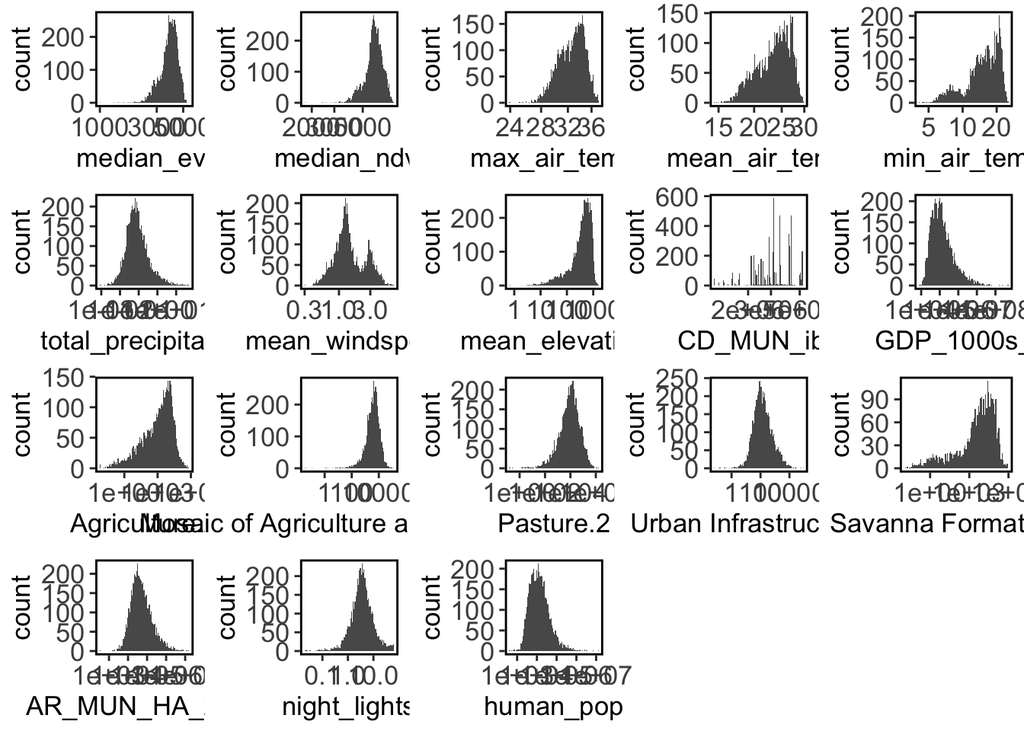

##### For this model we will just focus on yearly cases of VL in each municipality, averaging the predictors and summing the counts over months

```r
## For the first few models with the smallest number of covariates, just using the following covariates,
 ## summarized over months:
VL.year <- VL %>% group_by(munip_name, year) %>%
  summarize(
    vl_cases    = sum(vl_cases)
  , mean_temp   = mean(mean_air_temp)
  , mean_precip = mean(total_precipitation)
  , mean_pop    = mean(log10(human_pop))
  , mean_GDP    = mean(log10(GDP_1000s_R))
    ) %>% filter(munip_name != "") %>%
  mutate(mean_year = as.numeric(year))

## Cant have NA's so drop all of those
VL.year <- VL.year %>% drop_na() %>% ungroup()

## If debugging, run the model with only a few locations
if (debug.stan.model) {

## Pick a few of the locations with the largest numbers of cases
top_locs  <- VL %>% group_by(munip_name) %>% summarize(tot_cases = sum(vl_cases)) %>%
  arrange(desc(tot_cases)) %>% slice(1:deubg.top_samps) %>% dplyr::select(munip_name) %>% unname() %>% unlist()

## And a random smattering of other locations
rand_locs <- VL %>% group_by(munip_name) %>% summarize(tot_cases = sum(vl_cases)) %>%
  arrange(desc(tot_cases)) %>% filter(munip_name %notin% top_locs) %>% dplyr::select(munip_name) %>% unname() %>%
  unlist() %>% sample(debug.ran_samps)

rand_locs <- c(rand_locs, top_locs)

VL.year <- VL.year %>% filter(munip_name %in% rand_locs)

}
```

To compare the importance of individual predictors scale them

One method of debugging the first-level Bayesian model is to compare the predictions to a Frequentist model fit with a canned package. To do so we will also fit the simple model using lme4. We will do this first to see the model in what may be a more familiar form:

```r
## This model assumes a linear relationship between a few covariates and VL cases and allows the slope of cases over time to vary by municipality
if (file.exists("test.nb.s.Rds")) {

test.nb.s <- readRDS("test.nb.s.Rds")

} else {

test.nb.s <- glmer.nb(
  vl_cases ~ year + temp + precip + pop + (1 + year | munip_name)
  , data = VL.stan
  )

}
```

### A stan model includes all of the following blocks (for the complete model see “stan_models/Simple2_NB.stan”):

First, all data used in the model must be specified in a “data” block (note: many, many details about these data types can be found in the stan manual):

```r
"
data {

// data structure
int<lower=0> N;                    // number of observations
int<lower=0> y[N];                 // VL case counts

// bookkeeping for the random effects
int<lower=0> N_loc;                  // number of locations where counts are repeated (for the random effect)
int<lower=0> loc_id[N];            // ID of each location

// covariates
vector[N] temp;                    // temperature
vector[N] precip;                  // precipitation
vector[N] year;                    // year
vector[N] pop;                     // population size

 }
"
```

Second, all parameters in the model are declared in a “parameters” block:

```r
"
parameters {

// intercept and slope coefficients
real alpha_lambda_bar;                 // intercept for count piece
real temp_lambda_bar;                  // slope coefficients for probability piece
real precip_lambda_bar;
real year_lambda_bar;
real pop_lambda_bar;

// negative binomial variance (inverse, helps fitting)
real<lower=0> reciprocal_phi;

// random effect structure
real<lower=0> sigma_alpha_lambda;      // estimated variation among locations in the intercept (count)
vector[N_loc] eps_alpha_lambda;        // deviates for each place drawn from sigma_alpha (count)

real<lower=0> sigma_year_lambda;       // estimated variation among locations in slopes (count)
vector[N_loc] eps_year_lambda;         // deviates for each place drawn from the sigma_beta values (count)

}
"
```

Third, any derived parameters (e.g., linear predictors) are included in the “transformed parameters” block:

```r
"
transformed parameters {

real lambda_log[N];                   // linear predictor for count piece

real alpha_lambda[N_loc];             // location-specific intercepts for counts
real year_lambda[N_loc];              // location-specific year slopes

real<lower=0> phi;                    // negative binomial variance

// set up the location-specific deviates. Non-Centered Parameterization that can often help fitting: see Section 21.7 in the Stan Users Guide
for (i in 1:N_loc) {
 alpha_lambda[i] = alpha_lambda_bar + sigma_alpha_lambda * eps_alpha_lambda[i];
 year_lambda[i] = year_lambda_bar + sigma_year_lambda * eps_year_lambda[i];
}

// The linear predictor for each data point
for (j in 1:N) {
 lambda_log[j] = alpha_lambda[loc_id[j]] +
    temp_lambda_bar * temp[j] +
    precip_lambda_bar * precip[j] +
    year_lambda[loc_id[j]] * year[j] +
    pop_lambda_bar * pop[j];
}

phi = 1. / reciprocal_phi;

}
"
```

Fourth, the model itself is written out in a “model” block:

```r
"
model {

// priors. Break up the beta's according to some other independent data sources...

// fixed effects
   alpha_lambda_bar ~ normal(0, 3);
   temp_lambda_bar ~ normal(0, 3);
   year_lambda_bar ~ normal(0, 3);
   precip_lambda_bar ~ normal(0, 3);
   pop_lambda_bar ~ normal(0, 3);

// random effects
   sigma_alpha_lambda ~ cauchy(0, 5);
   sigma_year_lambda ~ cauchy(0, 5);

   eps_alpha_lambda ~ normal(0, 1);
   eps_year_lambda ~ normal(0, 1);

   reciprocal_phi ~ cauchy(0., 5);

// modify the likelihood (see the Stan User's Guide for details on this statement. But in brief, this line essentially says: modify the likelihood for data point n using the log negative binomial probability mass given the data conditioned on the location parameter lambda_log and the dispersion phi)
   for (n in 1:N) {

   target += neg_binomial_2_log_lpmf(y[n] | lambda_log[n], phi);

}

}
"
```

Fifth, any predictions are written out in a “generated quantities” block (note, I do not use this block in this model but do so in the subsequent model):

```r
"
generated quantities {

// for simulating values

}
"
```

Run the model:

```r
if (file.exists("Simple2_NB.stan.Rds")) {

stan.fit <- readRDS("Simple2_NB.stan.Rds")

} else {

stan.fit <- stan(
  file    = "stan_models/Simple2_NB.stan"
, data    = stan.data
, chains  = 3   ## Should be 3 or 4 for inference.
, iter    = ni  ## Should be big enough to get an effective sample size for all parameters to about 1000
, warmup  = nb
, thin    = nt  ## A larger number is needed the more autocorrelation present among sequential samples
, seed    = 1001
, control = list(
    adapt_delta = 0.95  ## For details on these parameters see the Stan manual. These modify the sampling algorithm. Often the defaults are fine (these are a bit larger than the defaults)
  , max_treedepth = 12
  ))

}
```

A few quick debugging steps for the stan model include:  
1. Checking for mixing of the chains: look for overlap of all chains; they should look like white noise with no pattern or drifitng; R hat at least less than 1.05 (preferably 1.01)  
2. Enough samples: look for effective sample size for all parameters of 1000 or more  
3. No divergent transitions (this is quite deep and beyond the scope of this document. Do some googling and read some more in-depth tutorials for dealing with divergent transitions)  
4. Unimodal posterior distributions (dealing with bimodal or other forms of ugly distributions is also a bit beyond the scope)  
5. Compare priors to posterios to check for information content of the model

These things can be checked manually (in a beautified way for supplemental plots this can be cumbersome, but some quick and dirty diagnostics are pretty fast) or using the extremely pleasant shinystan::launch_shinystan(model)

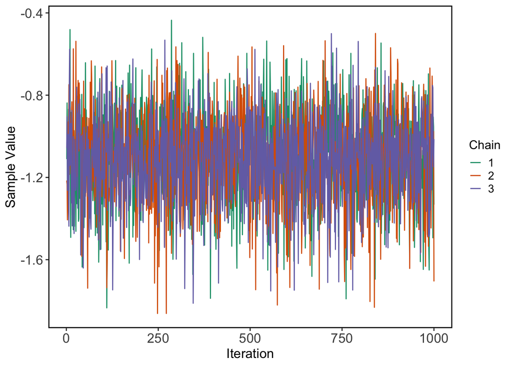

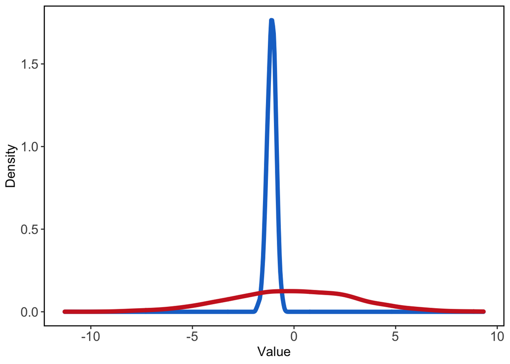

```
FALSE [1] 1.001042
```

```
FALSE [1] 2719.642
```

Compare the stan and lme4 coefficients and location-specific deviates:

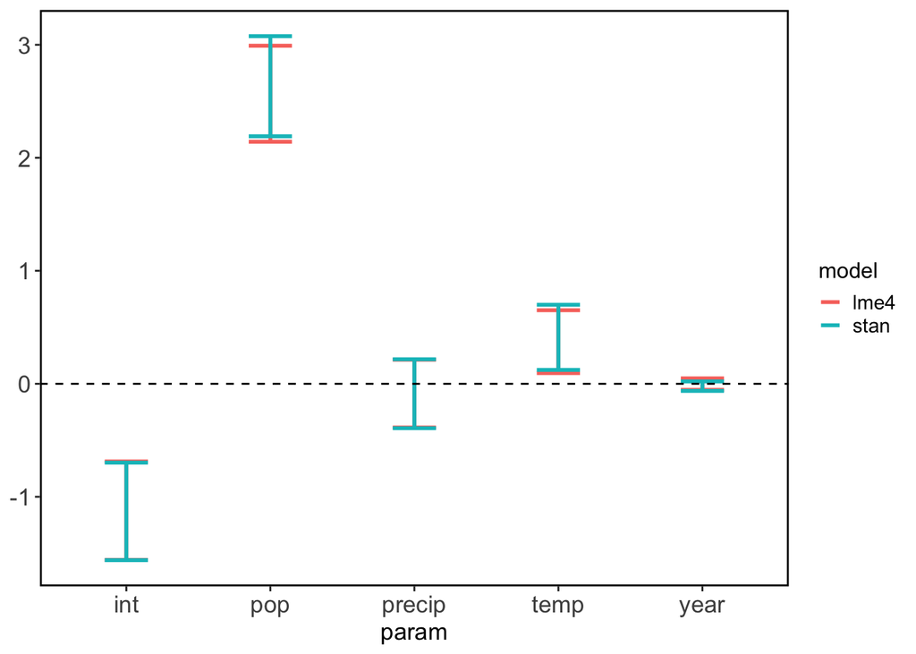

```r
## quick and dirty method of CI
lm_coef <- summary(test.nb.s)$coefficients
compare_coef <- data.frame(
  param     = rep(c("int", "year", "temp", "precip", "pop"), 2)
, model     = c(rep("lme4", 5), rep("stan", 5))
, freq_upr  = c(lm_coef[, 1] + lm_coef[, 2] * 1.96, summary(stan.fit)[[1]][c(1, 4, 2, 3, 5), 4])
, freq_lwr  = c(lm_coef[, 1] - lm_coef[, 2] * 1.96, summary(stan.fit)[[1]][c(1, 4, 2, 3, 5), 8])
)

## Extremely similar coefficient estimates
ggplot(compare_coef) +
  geom_errorbar(aes(x = param, ymin = freq_lwr, ymax = freq_upr, colour = model), lwd = 1, width = 0.3) +
  geom_hline(yintercept = 0, linetype = "dashed")
```

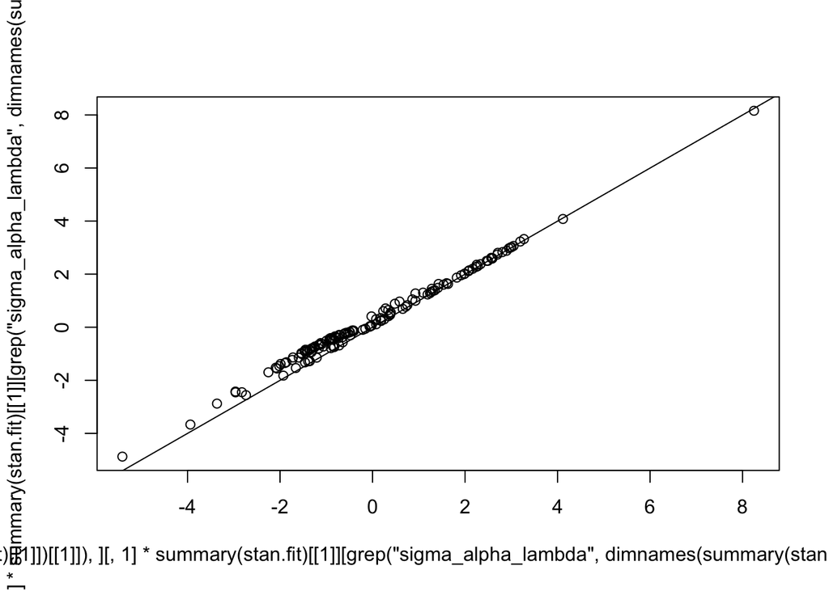

```r
## Very similar location intercept deviates
plot(
cbind(
  summary(stan.fit)[[1]][grep("eps_alpha_lambda", dimnames(summary(stan.fit)[[1]])[[1]]), ][, 1] *
  summary(stan.fit)[[1]][grep("sigma_alpha_lambda", dimnames(summary(stan.fit)[[1]])[[1]]), ][1]
, getME(test.nb.s, "b")[seq(1, nrow(getME(test.nb.s, "b")), by = 2), 1])
); abline(a = 0, b = 1)
```

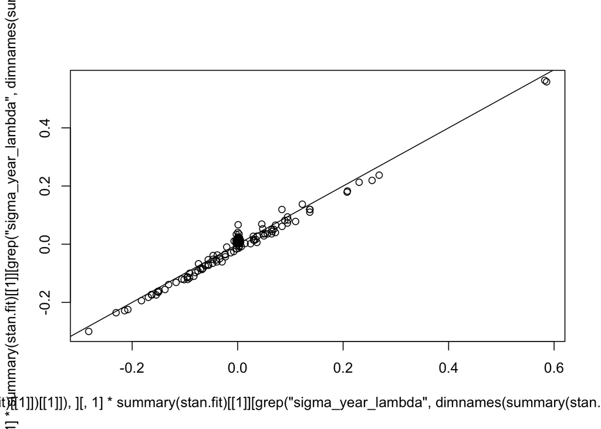

```r
## and very similar location slope deviates
plot(
cbind(
  summary(stan.fit)[[1]][grep("eps_year_lambda", dimnames(summary(stan.fit)[[1]])[[1]]), ][, 1] *
  summary(stan.fit)[[1]][grep("sigma_year_lambda", dimnames(summary(stan.fit)[[1]])[[1]]), 1]
, getME(test.nb.s, "b")[seq(2, nrow(getME(test.nb.s, "b")), by = 2), 1])
); abline(a = 0, b = 1)
```

##### The next model (“stan_models/NB.ZI.F.S.stan”) jumps *many* steps and includes:

1. Covariates and random effects in the binomial piece of the model
2. A smoothing term (spline) over years that vary by location
3. Forcasting for two years  
   (for a complete list of changes see “VL_stan.R”)

The full model looks like this:

```r
"
data {

  // ** In sample bookkeeping **
  int<lower=0> N;                      // number of observations
  int<lower=0> y[N];                   // VL case counts
  int<lower=0> N_loc;                      // number of locations where counts are repeated (for the random effect)
  int<lower=0> loc_id[N];                // ID of each location

  // ** In sample covariates **
  vector[N] temp;                      // temperature
  vector[N] precip;                    // precipitation
  vector[N] pop;                       // population
  vector[N] gdp;                       // gdp
  vector[N] area;                      // area
  vector[N] ag;                        // ag
  vector[N] ndvi;                      // ndvi

  int<lower=0> year[N];                // year
  int<lower=0> max_year;               // the largest year index (for the spline)

  // ** Out of Sample bookkeeping
  int<lower=0> N_out;                  // number of observations for out of sample predictions
  int<lower=0> N_loc_out;                // number of locations where counts are repeated (for the random effect) for out of sample predictions
  int<lower=0> loc_id_out[N_out];      // ID of each location for out of sample predictions

  // ** Out of Sample -covariates-
  vector[N_loc_out] temp_out_mean;              // temperature
  vector[N_loc_out] precip_out_mean;            // precipitation
  vector[N_loc_out] pop_out_mean;               // population
  vector[N_loc_out] gdp_out_mean;               // gdp
  vector[N_loc_out] area_out_mean;              // area
  vector[N_loc_out] ag_out_mean;                // ag
  vector[N_loc_out] ndvi_out_mean;              // ndvi

  vector[N_loc_out] temp_out_sd;                // temperature
  vector[N_loc_out] precip_out_sd;              // precipitation
  vector[N_loc_out] pop_out_sd;                 // population
  vector[N_loc_out] gdp_out_sd;                 // gdp
  vector[N_loc_out] area_out_sd;                // area
  vector[N_loc_out] ag_out_sd;                  // ag
  vector[N_loc_out] ndvi_out_sd;                // ndvi

}

parameters {

  // ** Fixed Effects **

  // ** Intercepts **
  real alpha_theta_bar;                // -grand- (given the presence of a random effect, using this language) intercept for probability piece
  real alpha_lambda_bar;               // -grand- intercept for count piece

  // ** Slopes (linear terms) **

  // ** probability piece **
  real gdp_theta_bar;                  // all -grand- slopes follow: COVARIATE_MODEL PIECE_bar

  // ** count piece **
  real temp_lambda_bar;
  real precip_lambda_bar;
  real pop_lambda_bar;
  real area_lambda_bar;
  real ag_lambda_bar;
  real ndvi_lambda_bar;

  // ** Slopes (higher order terms) **

  // ** count piece **
  real temp_lambda_bar_sq;                 // all higher-order polynomials have the details as the last piece, i.e. XXXX_sq for a squared term
  real precip_lambda_bar_sq;
  real pop_lambda_bar_sq;
  real area_lambda_bar_sq;
  real ndvi_lambda_bar_sq;

  vector[max_year-1] year_deltas_bar;      // Year_deltas shorter than max_years, because the first delta logically has to be 0

  // ** Variance/Dispersion **
  real<lower=0, upper=20> reciprocal_phi;  // putting an upper bound for constraints (20 is _really_ big)

  real<lower=0, upper=10> delta_sigma;     // Ghitza & Gelman used normal(delta[i-1],1) for sampling deltas, but that can lead to overfitting, so use a hyperprior

  // ** Random Effects, Non-Centered Parameterization, see Section 21.7 in the Stan Users Guide **

  // ** intercepts **
  real<lower=0> sigma_alpha_theta;         // estimated variation among locations in the intercept (probability)
  vector[N_loc] eps_alpha_theta;           // deviates for each place drawn from sigma_alpha (probability)

  real<lower=0> sigma_alpha_lambda;        // estimated variation among locations in the intercept (count)
  vector[N_loc] eps_alpha_lambda;          // deviates for each place drawn from sigma_alpha (count)

  // ** slopes **
  real<lower=0> sigma_year_lambda;       // estimated variation among locations in the year variation (count)
  matrix[N_loc, max_year-1] eps_year_deltas;

  // ** Out of sample -covariates- **

  vector[N_loc_out] temp_out;              // temperature
  vector[N_loc_out] precip_out;            // precipitation
  vector[N_loc_out] pop_out;               // population
  vector[N_loc_out] gdp_out;               // gdp
  vector[N_loc_out] area_out;              // area
  vector[N_loc_out] ag_out;                // ag
  vector[N_loc_out] ndvi_out;              // ndvi

}

transformed parameters {

  // ** random effect deviates **
  real alpha_theta[N_loc];                  // location-specific intercepts for probability piece
  real alpha_lambda[N_loc];                 // location-specific intercepts for counts

  // ** linear predictors for probability **
  real<lower=0, upper=1> theta[N];          // linear predictor for probability piece
  real<lower=0, upper=1> theta_out[N_out];  // linear predictor for probability piece

  real inv_theta[N];                        // linear predictor for probability piece
  real inv_theta_out[N_out];                // linear predictor for probability piece

  // ** linear predictors for count **
  real lambda_log[N];                       // linear predictor for count piece
  real lambda_log_out[N_out];               // linear predictor for count piece for out of sample predictions

  // ** year smoother setup **
  matrix[N_loc, max_year] year_mu;          // year_mu will be the modeled effect of year on VL count at each year
  vector[max_year] real_deltas_bar;         // real_deltas is just year_deltas with 0 concatenated to the front
  matrix[N_loc, max_year] real_deltas_eps;  // random deviates

  // ** dispersion, variance terms **
  real phi;                                 // Dispersion of negative binomial

  real_deltas_bar[1] = 0.0;

  for (i in 1:N_loc) {
    real_deltas_eps[i, 1] = 0.0;
  }

  for(i in 1:(max_year-1)) {
    real_deltas_bar[i+1] = year_deltas_bar[i];
    real_deltas_eps[, i+1] = eps_year_deltas[, i];
   }

  // The trick here is to use cumulative sum of deltas (which are the year to year individual smoothing terms)
  for (i in 1:N_loc) {
    year_mu[i, ] = to_row_vector(cumulative_sum(real_deltas_bar + sigma_year_lambda * to_vector(real_deltas_eps[i, ])));
  }

  // ** Build the linear predictors  **

for (i in 1:N_loc) {

  alpha_theta[i] = alpha_theta_bar + sigma_alpha_theta * eps_alpha_theta[i];
  alpha_lambda[i] = alpha_lambda_bar + sigma_alpha_lambda * eps_alpha_lambda[i];

}

  // ** in sample (fitting) **

for (j in 1:N) {

  lambda_log[j] = alpha_lambda[loc_id[j]] +
    temp_lambda_bar * temp[j] +
    temp_lambda_bar_sq * square(temp[j]) +
    precip_lambda_bar * precip[j] +
    precip_lambda_bar_sq * square(precip[j]) +
    pop_lambda_bar * pop[j] +
    pop_lambda_bar_sq * square(pop[j]) +
    area_lambda_bar * area[j] +
    area_lambda_bar_sq * square(area[j]) +
    ag_lambda_bar * ag[j] +
    ndvi_lambda_bar * ndvi[j] +
    ndvi_lambda_bar_sq * square(ndvi[j]) +
    year_mu[loc_id[j], year[j]];

  inv_theta[j] = alpha_theta[loc_id[j]] + gdp_theta_bar * gdp[j];

}

  theta = inv_logit(inv_theta);

  // ** out of sample (predicting) **

for (jj in 1:N_out) {

  lambda_log_out[jj] = alpha_lambda[loc_id_out[jj]] +
    temp_lambda_bar * temp_out[loc_id_out[jj]] +
    temp_lambda_bar_sq * square(temp_out[loc_id_out[jj]]) +
    precip_lambda_bar * precip_out[loc_id_out[jj]] +
    precip_lambda_bar_sq * square(precip_out[loc_id_out[jj]]) +
    pop_lambda_bar * pop_out[loc_id_out[jj]] +
    pop_lambda_bar_sq * square(pop_out[loc_id_out[jj]]) +
    area_lambda_bar * area_out[loc_id_out[jj]] +
    area_lambda_bar_sq * square(area_out[loc_id_out[jj]]) +
    ag_lambda_bar * ag_out[loc_id_out[jj]] +
    ndvi_lambda_bar * ndvi_out[loc_id_out[jj]] +
    ndvi_lambda_bar_sq * square(ndvi_out[loc_id_out[jj]]) +
    year_mu[loc_id_out[jj], max_year];                            // Use the last cumulative year smooth for forward projecting;

  inv_theta_out[jj] = alpha_theta[loc_id_out[jj]] + gdp_theta_bar * gdp_out[loc_id_out[jj]];

}

  theta_out = inv_logit(inv_theta_out);

  phi = 1. / reciprocal_phi;

}

model {

// ** Priors. **

// ** Fixed effects **
   alpha_theta_bar ~ normal(0, 3);
   gdp_theta_bar ~ normal(0, 3);

   alpha_lambda_bar ~ normal(0, 2);

   temp_lambda_bar ~ normal(0, 3);
   precip_lambda_bar ~ normal(0, 3);
   pop_lambda_bar ~ normal(0, 3);
   area_lambda_bar ~ normal(0, 3);
   ag_lambda_bar ~ normal(0, 3);
   ndvi_lambda_bar ~ normal(0, 3);

   temp_lambda_bar_sq ~ normal(0, 1);
   precip_lambda_bar_sq ~ normal(0, 1);
   pop_lambda_bar_sq ~ normal(0, 1);
   area_lambda_bar_sq ~ normal(0, 1);
   ndvi_lambda_bar_sq ~ normal(0, 1);

   // year smoother: The first time_delta should be less constrained than the rest. delta_sigma could be very small,
    // and if so, the subsequent delta values would be constrained to be too close to 0.
    year_deltas_bar[1] ~ normal(0, 3);

    for(i in 2:(max_year-1)) {
      year_deltas_bar[i] ~ normal(year_deltas_bar[i-1], delta_sigma);
    }

// ** Out of sample -covariates- **

for (i in 1:N_loc_out) {
 temp_out[i] ~ normal(temp_out_mean[i], temp_out_sd[i]);
 precip_out[i] ~ normal(precip_out_mean[i], precip_out_sd[i]);
 pop_out[i] ~ normal(pop_out_mean[i], pop_out_sd[i]);
 gdp_out[i] ~ normal(gdp_out_mean[i], gdp_out_sd[i]);
 area_out[i] ~ normal(area_out_mean[i], area_out_sd[i]);
 ag_out[i] ~ normal(ag_out_mean[i], ag_out_sd[i]);
 ndvi_out[i] ~ normal(ndvi_out_mean[i], ndvi_out_sd[i]);
}

// ** Random effects **

   sigma_alpha_theta ~ inv_gamma(3.5, 1);
   eps_alpha_theta ~ normal(0, 1);

   sigma_alpha_lambda ~ inv_gamma(3.5, 1);
   eps_alpha_lambda ~ normal(0, 1);

   sigma_year_lambda ~ inv_gamma(1, 1);

   for (i in 1:N_loc) {
     eps_year_deltas[i, ] ~ normal(0, 1);
   }

   reciprocal_phi ~ inv_gamma(3.5, 1);


// ** modify the likelihood **

for(n in 1:N) {

if (y[n] == 0) {

      target += log_sum_exp(bernoulli_lpmf(1 | theta[n]),
                             bernoulli_lpmf(0 | theta[n])
                           + neg_binomial_2_log_lpmf(y[n] | lambda_log[n], phi));

    } else {

      target += bernoulli_lpmf(0 | theta[n])
                  + neg_binomial_2_log_lpmf(y[n] | lambda_log[n], phi);

    }
  }
}

generated quantities {

// ** Estimates for both in- and out-of-sample predictions

 int<lower=0> y_sim[N];
 int zero_pred;
 real mu[N];

 int<lower=0> y_sim_out[N_out];
 int zero_pred_out;
 real mu_out[N_out];

 mu = exp(lambda_log);
 mu_out = exp(lambda_log_out);

// ** In sample predictions **

 for(n in 1:N) {

 zero_pred    = bernoulli_rng(theta[n]);
 y_sim[n]     = (1 - zero_pred) * neg_binomial_2_rng(mu[n], phi);

  }

// ** Out of sample predictions **

 for(nn in 1:N_out) {

  zero_pred_out = bernoulli_rng(theta_out[nn]);
  y_sim_out[nn] = (1 - zero_pred_out) * neg_binomial_2_rng(mu_out[nn], phi);

  }

}
"
```

Save the diagnostics for shinystan but at least plot some output. Histogram of location-specific intercept deviates:

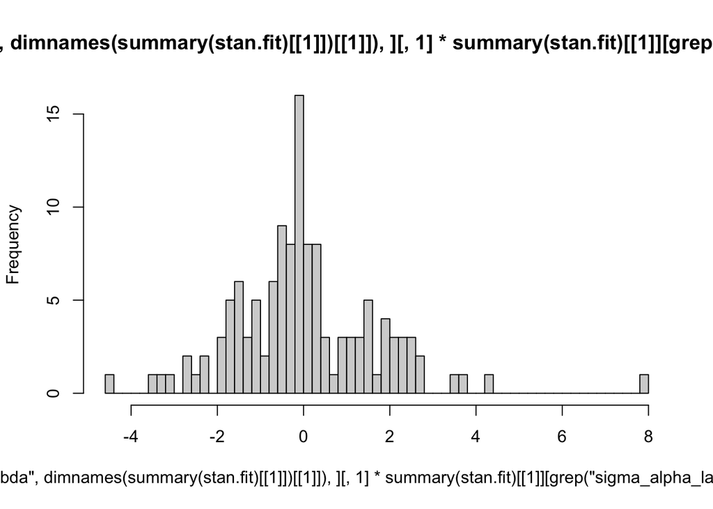

Some coefficients:

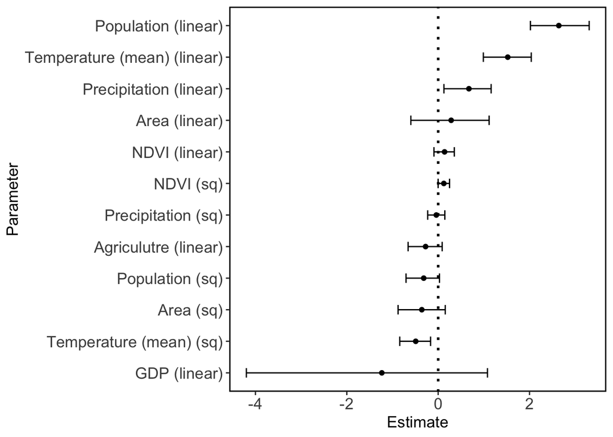

Some forecasts for a few locations:

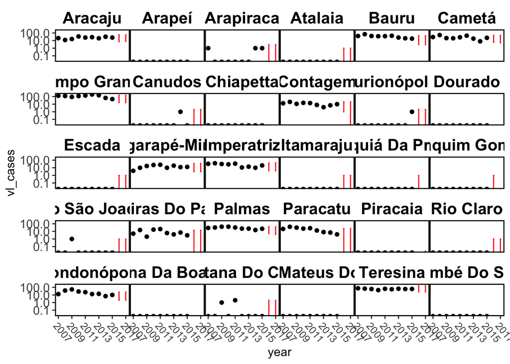